# TelecomCustomerChurn

```python
import numpy as np
import pandas as pd
import matplotlib.pyplot as plt
import seaborn as sns
import sklearn
from sklearn.model_selection import train_test_split
from sklearn.preprocessing import StandardScaler
from sklearn.metrics import accuracy_score,confusion_matrix
from sklearn.linear_model import LogisticRegression
from sklearn.metrics import accuracy_score
import mysql.connector as my_con

import warnings
warnings.filterwarnings('ignore')
```

```python
# Connection setup
MYSQL_Connection = my_con.connect(user ='root',
            password= 'sqlpassword', ##Give your password
            host= 'localhost',
            database= 'TelecomCustomerChurn')

print(MYSQL_Connection)
```

```
<mysql.connector.connection_cext.CMySQLConnection object at 0x0000019FE4007400>
```

```python
df1 = pd.read_sql('SELECT * FROM telecomcustomerchurn1', con=MYSQL_Connection)
df1.head()
```

|  | customerID | gender | SeniorCitizen | Partner | Dependents | tenure | PhoneService | MultipleLines | InternetService | OnlineSecurity |
| --- | --- | --- | --- | --- | --- | --- | --- | --- | --- | --- |
| 0 | 0002-ORFBO | Female | 0 | Yes | Yes | 9 | Yes | No | DSL | No\r |
| 1 | 0003-MKNFE | Male | 0 | No | No | 9 | Yes | Yes | DSL | No\r |
| 2 | 0004-TLHLJ | Male | 0 | No | No | 4 | Yes | No | Fiber optic | No\r |
| 3 | 0011-IGKFF | Male | 1 | Yes | No | 13 | Yes | No | Fiber optic | No\r |
| 4 | 0013-EXCHZ | Female | 1 | Yes | No | 3 | Yes | No | Fiber optic | No\r |

```python
df1.shape
```

```
(7043, 10)
```

```python
df2 = pd.read_sql('SELECT * FROM telecomcustomerchurn2', con=MYSQL_Connection)
df2.head()
```

|  | customerID | OnlineBackup | DeviceProtection | TechSupport | StreamingTV | StreamingMovies | Contract | PaperlessBilling | PaymentMethod | MonthlyCharges | TotalCharges | Churn |
| --- | --- | --- | --- | --- | --- | --- | --- | --- | --- | --- | --- | --- |
| 0 | 0002-ORFBO | Yes | No | Yes | Yes | No | One year | Yes | Mailed check | 65.6 | 593.30 | No\r |
| 1 | 0003-MKNFE | No | No | No | No | Yes | Month-to-month | No | Mailed check | 59.9 | 542.40 | No\r |
| 2 | 0004-TLHLJ | No | Yes | No | No | No | Month-to-month | Yes | Electronic check | 73.9 | 280.85 | Yes\r |
| 3 | 0011-IGKFF | Yes | Yes | No | Yes | Yes | Month-to-month | Yes | Electronic check | 98.0 | 1237.85 | Yes\r |
| 4 | 0013-EXCHZ | No | No | Yes | Yes | No | Month-to-month | Yes | Mailed check | 83.9 | 267.40 | Yes\r |

```python
df2.shape
```

```
(7043, 12)
```

```python
df = df1.merge(df2, how='outer', on='customerID')
```

```python
df.shape
```

```
(7043, 21)
```

##### Here we can observe that there are 21 columns/features in the dataset with 7043 entried

```python
df.describe()
```

|  | SeniorCitizen | tenure | MonthlyCharges | TotalCharges |
| --- | --- | --- | --- | --- |
| count | 7043.000000 | 7043.000000 | 7043.000000 | 7043.000000 |
| mean | 0.162147 | 32.371149 | 64.761692 | 2279.734304 |
| std | 0.368612 | 24.559481 | 30.090047 | 2266.794470 |
| min | 0.000000 | 0.000000 | 18.250000 | 0.000000 |
| 25% | 0.000000 | 9.000000 | 35.500000 | 398.550000 |
| 50% | 0.000000 | 29.000000 | 70.350000 | 1394.550000 |
| 75% | 0.000000 | 55.000000 | 89.850000 | 3786.600000 |
| max | 1.000000 | 72.000000 | 118.750000 | 8684.800000 |

##### We can observe that customers are spending an average of almost 65 dollars per month and availing services for an average of 32 months. They are also paying an average of 2280 dollars in their tenure

```python
print(df.info())
```

```
<class 'pandas.core.frame.DataFrame'>
Int64Index: 7043 entries, 0 to 7042
Data columns (total 21 columns):
 #   Column            Non-Null Count  Dtype
---  ------            --------------  -----
 0   customerID        7043 non-null   object
 1   gender            7043 non-null   object
 2   SeniorCitizen     7043 non-null   int64
 3   Partner           7043 non-null   object
 4   Dependents        7043 non-null   object
 5   tenure            7043 non-null   int64
 6   PhoneService      7043 non-null   object
 7   MultipleLines     7043 non-null   object
 8   InternetService   7043 non-null   object
 9   OnlineSecurity    7043 non-null   object
 10  OnlineBackup      7043 non-null   object
 11  DeviceProtection  7043 non-null   object
 12  TechSupport       7043 non-null   object
 13  StreamingTV       7043 non-null   object
 14  StreamingMovies   7043 non-null   object
 15  Contract          7043 non-null   object
 16  PaperlessBilling  7043 non-null   object
 17  PaymentMethod     7043 non-null   object
 18  MonthlyCharges    7043 non-null   float64
 19  TotalCharges      7043 non-null   float64
 20  Churn             7043 non-null   object
dtypes: float64(2), int64(2), object(17)
memory usage: 1.2+ MB
None
```

##### There are 17 categorical columns and 4 numerical columns detailing the customer information

```python
df["TotalCharges"] = df["TotalCharges"].replace({'0':np.nan, 0:np.nan})

for column in df:
    sumofnan = df[column].isnull().sum()
    print("The percentage of null values in " + column + " = " + str((sumofnan/len(df.index))*100))
print("Dropping rows with null values...")
df = df.dropna()
```

```
The percentage of null values in customerID = 0.0
The percentage of null values in gender = 0.0
The percentage of null values in SeniorCitizen = 0.0
The percentage of null values in Partner = 0.0
The percentage of null values in Dependents = 0.0
The percentage of null values in tenure = 0.0
The percentage of null values in PhoneService = 0.0
The percentage of null values in MultipleLines = 0.0
The percentage of null values in InternetService = 0.0
The percentage of null values in OnlineSecurity = 0.0
The percentage of null values in OnlineBackup = 0.0
The percentage of null values in DeviceProtection = 0.0
The percentage of null values in TechSupport = 0.0
The percentage of null values in StreamingTV = 0.0
The percentage of null values in StreamingMovies = 0.0
The percentage of null values in Contract = 0.0
The percentage of null values in PaperlessBilling = 0.0
The percentage of null values in PaymentMethod = 0.0
The percentage of null values in MonthlyCharges = 0.0
The percentage of null values in TotalCharges = 0.1561834445548772
The percentage of null values in Churn = 0.0
Dropping rows with null values...
```

#### Replacing 0 value in TotalCharges with NULL and dropping NULL rows as they are redundant for analysis

```python
print(df.info())
```

```
<class 'pandas.core.frame.DataFrame'>
Int64Index: 7032 entries, 0 to 7042
Data columns (total 21 columns):
 #   Column            Non-Null Count  Dtype
---  ------            --------------  -----
 0   customerID        7032 non-null   object
 1   gender            7032 non-null   object
 2   SeniorCitizen     7032 non-null   int64
 3   Partner           7032 non-null   object
 4   Dependents        7032 non-null   object
 5   tenure            7032 non-null   int64
 6   PhoneService      7032 non-null   object
 7   MultipleLines     7032 non-null   object
 8   InternetService   7032 non-null   object
 9   OnlineSecurity    7032 non-null   object
 10  OnlineBackup      7032 non-null   object
 11  DeviceProtection  7032 non-null   object
 12  TechSupport       7032 non-null   object
 13  StreamingTV       7032 non-null   object
 14  StreamingMovies   7032 non-null   object
 15  Contract          7032 non-null   object
 16  PaperlessBilling  7032 non-null   object
 17  PaymentMethod     7032 non-null   object
 18  MonthlyCharges    7032 non-null   float64
 19  TotalCharges      7032 non-null   float64
 20  Churn             7032 non-null   object
dtypes: float64(2), int64(2), object(17)
memory usage: 1.2+ MB
None
```

```python
df.shape
```

```
(7032, 21)
```

##### There were 11 rows with NULL values and were dropped

```python
dup_series = df.duplicated()
dup = 0
for d in dup_series:
    if d is True:
        dup += 1
print("There are {0} duplicate entries in the database".format(dup))
```

```
There are 0 duplicate entries in the database
```

###### There are no duplicate rows in the database

```python
df = df.drop_duplicates()
print(df.info())
```

```
<class 'pandas.core.frame.DataFrame'>
Int64Index: 7032 entries, 0 to 7042
Data columns (total 21 columns):
 #   Column            Non-Null Count  Dtype
---  ------            --------------  -----
 0   customerID        7032 non-null   object
 1   gender            7032 non-null   object
 2   SeniorCitizen     7032 non-null   int64
 3   Partner           7032 non-null   object
 4   Dependents        7032 non-null   object
 5   tenure            7032 non-null   int64
 6   PhoneService      7032 non-null   object
 7   MultipleLines     7032 non-null   object
 8   InternetService   7032 non-null   object
 9   OnlineSecurity    7032 non-null   object
 10  OnlineBackup      7032 non-null   object
 11  DeviceProtection  7032 non-null   object
 12  TechSupport       7032 non-null   object
 13  StreamingTV       7032 non-null   object
 14  StreamingMovies   7032 non-null   object
 15  Contract          7032 non-null   object
 16  PaperlessBilling  7032 non-null   object
 17  PaymentMethod     7032 non-null   object
 18  MonthlyCharges    7032 non-null   float64
 19  TotalCharges      7032 non-null   float64
 20  Churn             7032 non-null   object
dtypes: float64(2), int64(2), object(17)
memory usage: 1.2+ MB
None
```

##### Dropping duplicates did not change row count, hence there are no duplicate rows

```python
df.drop('customerID', axis=1, inplace=True)
print(df.info())
```

```
<class 'pandas.core.frame.DataFrame'>
Int64Index: 7032 entries, 0 to 7042
Data columns (total 20 columns):
 #   Column            Non-Null Count  Dtype
---  ------            --------------  -----
 0   gender            7032 non-null   object
 1   SeniorCitizen     7032 non-null   int64
 2   Partner           7032 non-null   object
 3   Dependents        7032 non-null   object
 4   tenure            7032 non-null   int64
 5   PhoneService      7032 non-null   object
 6   MultipleLines     7032 non-null   object
 7   InternetService   7032 non-null   object
 8   OnlineSecurity    7032 non-null   object
 9   OnlineBackup      7032 non-null   object
 10  DeviceProtection  7032 non-null   object
 11  TechSupport       7032 non-null   object
 12  StreamingTV       7032 non-null   object
 13  StreamingMovies   7032 non-null   object
 14  Contract          7032 non-null   object
 15  PaperlessBilling  7032 non-null   object
 16  PaymentMethod     7032 non-null   object
 17  MonthlyCharges    7032 non-null   float64
 18  TotalCharges      7032 non-null   float64
 19  Churn             7032 non-null   object
dtypes: float64(2), int64(2), object(16)
memory usage: 1.1+ MB
None
```

##### Removed the column "customer ID" as is it is redundant for data analysis

```python
df["OnlineSecurity"] = df["OnlineSecurity"].str.replace('\r', '')
df["Churn"] = df["Churn"].str.replace('\r', '')
df.head()
```

|  | gender | SeniorCitizen | Partner | Dependents | tenure | PhoneService | MultipleLines | InternetService | OnlineSecurity | OnlineBackup | DeviceProtection | TechSupport | StreamingTV | StreamingMovies | Contract | PaperlessBilling | PaymentMethod | MonthlyCharges | TotalCharges | Churn |
| --- | --- | --- | --- | --- | --- | --- | --- | --- | --- | --- | --- | --- | --- | --- | --- | --- | --- | --- | --- | --- |
| 0 | Female | 0 | Yes | Yes | 9 | Yes | No | DSL | No | Yes | No | Yes | Yes | No | One year | Yes | Mailed check | 65.6 | 593.30 | No |
| 1 | Male | 0 | No | No | 9 | Yes | Yes | DSL | No | No | No | No | No | Yes | Month-to-month | No | Mailed check | 59.9 | 542.40 | No |
| 2 | Male | 0 | No | No | 4 | Yes | No | Fiber optic | No | No | Yes | No | No | No | Month-to-month | Yes | Electronic check | 73.9 | 280.85 | Yes |
| 3 | Male | 1 | Yes | No | 13 | Yes | No | Fiber optic | No | Yes | Yes | No | Yes | Yes | Month-to-month | Yes | Electronic check | 98.0 | 1237.85 | Yes |
| 4 | Female | 1 | Yes | No | 3 | Yes | No | Fiber optic | No | No | No | Yes | Yes | No | Month-to-month | Yes | Mailed check | 83.9 | 267.40 | Yes |

##### Replacing redundant part of string

```python
def get_unique(df, cols):
    for c in cols:
        print(df[c].value_counts())
        print("\n")
```

```python
cols = ["gender", "Partner", "Dependents", "PhoneService", "MultipleLines",
        "InternetService", "OnlineSecurity", "OnlineBackup", "DeviceProtection", "TechSupport", "StreamingTV",
        "StreamingMovies", "Contract", "PaperlessBilling", "PaymentMethod", "Churn"]
get_unique(df,cols)
```

```
Male      3549
Female    3483
Name: gender, dtype: int64


No     3639
Yes    3393
Name: Partner, dtype: int64


No     4933
Yes    2099
Name: Dependents, dtype: int64


Yes    6352
No      680
Name: PhoneService, dtype: int64


No                  3385
Yes                 2967
No phone service     680
Name: MultipleLines, dtype: int64


Fiber optic    3096
DSL            2416
No             1520
Name: InternetService, dtype: int64


No                     3497
Yes                    2015
No internet service    1520
Name: OnlineSecurity, dtype: int64


No                     3087
Yes                    2425
```

[output cut: 34 more lines]

```
Yes    4168
No     2864
Name: PaperlessBilling, dtype: int64


Electronic check             2365
Mailed check                 1604
Bank transfer (automatic)    1542
Credit card (automatic)      1521
Name: PaymentMethod, dtype: int64


No     5163
Yes    1869
Name: Churn, dtype: int64
```

### The target variable Churn shows that majorly people continue with their subscriptions and hence the data seems to be skewed towards Not Churning

```python
def encode_2cats(df, cols):
    df = df.replace(cols)
    return df
def encode_vars(df, cols):
    df = pd.get_dummies(df, columns = cols, prefix = cols)
    return df
```

```python
col2cats = {
    "gender" : {"Male": 1, "Female": 0},
    "Partner": {"Yes": 1, "No": 0, },
    "Dependents": {"Yes": 1, "No": 0, },
    "PhoneService": {"Yes": 1, "No": 0, },
    "PaperlessBilling": {"Yes": 1, "No": 0, },
    "Churn": {"Yes": 1, "No": 0, },
          }

cols = ["MultipleLines", "InternetService", "OnlineSecurity", "OnlineBackup", "DeviceProtection", "TechSupport", "StreamingTV", "StreamingMovies", "Contract", "PaymentMethod"]


df.head()
```

|  | gender | SeniorCitizen | Partner | Dependents | tenure | PhoneService | MultipleLines | InternetService | OnlineSecurity | OnlineBackup | DeviceProtection | TechSupport | StreamingTV | StreamingMovies | Contract | PaperlessBilling | PaymentMethod | MonthlyCharges | TotalCharges | Churn |
| --- | --- | --- | --- | --- | --- | --- | --- | --- | --- | --- | --- | --- | --- | --- | --- | --- | --- | --- | --- | --- |
| 0 | Female | 0 | Yes | Yes | 9 | Yes | No | DSL | No | Yes | No | Yes | Yes | No | One year | Yes | Mailed check | 65.6 | 593.30 | No |
| 1 | Male | 0 | No | No | 9 | Yes | Yes | DSL | No | No | No | No | No | Yes | Month-to-month | No | Mailed check | 59.9 | 542.40 | No |
| 2 | Male | 0 | No | No | 4 | Yes | No | Fiber optic | No | No | Yes | No | No | No | Month-to-month | Yes | Electronic check | 73.9 | 280.85 | Yes |
| 3 | Male | 1 | Yes | No | 13 | Yes | No | Fiber optic | No | Yes | Yes | No | Yes | Yes | Month-to-month | Yes | Electronic check | 98.0 | 1237.85 | Yes |
| 4 | Female | 1 | Yes | No | 3 | Yes | No | Fiber optic | No | No | No | Yes | Yes | No | Month-to-month | Yes | Mailed check | 83.9 | 267.40 | Yes |

```python
df_encoded = df.copy()
```

```python
df_encoded = encode_2cats(df_encoded,col2cats)
df_encoded = encode_vars(df_encoded,cols)
```

```python
df.head()
```

|  | gender | SeniorCitizen | Partner | Dependents | tenure | PhoneService | MultipleLines | InternetService | OnlineSecurity | OnlineBackup | DeviceProtection | TechSupport | StreamingTV | StreamingMovies | Contract | PaperlessBilling | PaymentMethod | MonthlyCharges | TotalCharges | Churn |
| --- | --- | --- | --- | --- | --- | --- | --- | --- | --- | --- | --- | --- | --- | --- | --- | --- | --- | --- | --- | --- |
| 0 | Female | 0 | Yes | Yes | 9 | Yes | No | DSL | No | Yes | No | Yes | Yes | No | One year | Yes | Mailed check | 65.6 | 593.30 | No |
| 1 | Male | 0 | No | No | 9 | Yes | Yes | DSL | No | No | No | No | No | Yes | Month-to-month | No | Mailed check | 59.9 | 542.40 | No |
| 2 | Male | 0 | No | No | 4 | Yes | No | Fiber optic | No | No | Yes | No | No | No | Month-to-month | Yes | Electronic check | 73.9 | 280.85 | Yes |
| 3 | Male | 1 | Yes | No | 13 | Yes | No | Fiber optic | No | Yes | Yes | No | Yes | Yes | Month-to-month | Yes | Electronic check | 98.0 | 1237.85 | Yes |
| 4 | Female | 1 | Yes | No | 3 | Yes | No | Fiber optic | No | No | No | Yes | Yes | No | Month-to-month | Yes | Mailed check | 83.9 | 267.40 | Yes |

```python
df_encoded.head()
```

|  | gender | SeniorCitizen | Partner | Dependents | tenure | PhoneService | PaperlessBilling | MonthlyCharges | TotalCharges | Churn | ... | StreamingMovies_No | StreamingMovies_No internet service | StreamingMovies_Yes | Contract_Month-to-month | Contract_One year | Contract_Two year | PaymentMethod_Bank transfer (automatic) | PaymentMethod_Credit card (automatic) | PaymentMethod_Electronic check | PaymentMethod_Mailed check |
| --- | --- | --- | --- | --- | --- | --- | --- | --- | --- | --- | --- | --- | --- | --- | --- | --- | --- | --- | --- | --- | --- |
| 0 | 0 | 0 | 1 | 1 | 9 | 1 | 1 | 65.6 | 593.30 | 0 | ... | 1 | 0 | 0 | 0 | 1 | 0 | 0 | 0 | 0 | 1 |
| 1 | 1 | 0 | 0 | 0 | 9 | 1 | 0 | 59.9 | 542.40 | 0 | ... | 0 | 0 | 1 | 1 | 0 | 0 | 0 | 0 | 0 | 1 |
| 2 | 1 | 0 | 0 | 0 | 4 | 1 | 1 | 73.9 | 280.85 | 1 | ... | 1 | 0 | 0 | 1 | 0 | 0 | 0 | 0 | 1 | 0 |
| 3 | 1 | 1 | 1 | 0 | 13 | 1 | 1 | 98.0 | 1237.85 | 1 | ... | 0 | 0 | 1 | 1 | 0 | 0 | 0 | 0 | 1 | 0 |
| 4 | 0 | 1 | 1 | 0 | 3 | 1 | 1 | 83.9 | 267.40 | 1 | ... | 1 | 0 | 0 | 1 | 0 | 0 | 0 | 0 | 0 | 1 |

5 rows × 41 columns

```python
df_encoded.shape
```

```
(7032, 41)
```

```python
df_encoded.describe()
```

|  | gender | SeniorCitizen | Partner | Dependents | tenure | PhoneService | PaperlessBilling | MonthlyCharges | TotalCharges | Churn | ... | StreamingMovies_No | StreamingMovies_No internet service | StreamingMovies_Yes | Contract_Month-to-month | Contract_One year | Contract_Two year | PaymentMethod_Bank transfer (automatic) | PaymentMethod_Credit card (automatic) | PaymentMethod_Electronic check | PaymentMethod_Mailed check |
| --- | --- | --- | --- | --- | --- | --- | --- | --- | --- | --- | --- | --- | --- | --- | --- | --- | --- | --- | --- | --- | --- |
| count | 7032.000000 | 7032.000000 | 7032.000000 | 7032.000000 | 7032.000000 | 7032.000000 | 7032.000000 | 7032.000000 | 7032.000000 | 7032.000000 | ... | 7032.000000 | 7032.000000 | 7032.000000 | 7032.000000 | 7032.000000 | 7032.000000 | 7032.000000 | 7032.000000 | 7032.000000 | 7032.000000 |
| mean | 0.504693 | 0.162400 | 0.482509 | 0.298493 | 32.421786 | 0.903299 | 0.592719 | 64.798208 | 2283.300441 | 0.265785 | ... | 0.395478 | 0.216155 | 0.388367 | 0.551052 | 0.209329 | 0.239619 | 0.219283 | 0.216297 | 0.336320 | 0.228100 |
| std | 0.500014 | 0.368844 | 0.499729 | 0.457629 | 24.545260 | 0.295571 | 0.491363 | 30.085974 | 2266.771362 | 0.441782 | ... | 0.488988 | 0.411650 | 0.487414 | 0.497422 | 0.406858 | 0.426881 | 0.413790 | 0.411748 | 0.472483 | 0.419637 |
| min | 0.000000 | 0.000000 | 0.000000 | 0.000000 | 1.000000 | 0.000000 | 0.000000 | 18.250000 | 18.800000 | 0.000000 | ... | 0.000000 | 0.000000 | 0.000000 | 0.000000 | 0.000000 | 0.000000 | 0.000000 | 0.000000 | 0.000000 | 0.000000 |
| 25% | 0.000000 | 0.000000 | 0.000000 | 0.000000 | 9.000000 | 1.000000 | 0.000000 | 35.587500 | 401.450000 | 0.000000 | ... | 0.000000 | 0.000000 | 0.000000 | 0.000000 | 0.000000 | 0.000000 | 0.000000 | 0.000000 | 0.000000 | 0.000000 |
| 50% | 1.000000 | 0.000000 | 0.000000 | 0.000000 | 29.000000 | 1.000000 | 1.000000 | 70.350000 | 1397.475000 | 0.000000 | ... | 0.000000 | 0.000000 | 0.000000 | 1.000000 | 0.000000 | 0.000000 | 0.000000 | 0.000000 | 0.000000 | 0.000000 |
| 75% | 1.000000 | 0.000000 | 1.000000 | 1.000000 | 55.000000 | 1.000000 | 1.000000 | 89.862500 | 3794.737500 | 1.000000 | ... | 1.000000 | 0.000000 | 1.000000 | 1.000000 | 0.000000 | 0.000000 | 0.000000 | 0.000000 | 1.000000 | 0.000000 |
| max | 1.000000 | 1.000000 | 1.000000 | 1.000000 | 72.000000 | 1.000000 | 1.000000 | 118.750000 | 8684.800000 | 1.000000 | ... | 1.000000 | 1.000000 | 1.000000 | 1.000000 | 1.000000 | 1.000000 | 1.000000 | 1.000000 | 1.000000 | 1.000000 |

8 rows × 41 columns

```python
df_encoded.info()
```

```
<class 'pandas.core.frame.DataFrame'>
Int64Index: 7032 entries, 0 to 7042
Data columns (total 41 columns):
 #   Column                                   Non-Null Count  Dtype
---  ------                                   --------------  -----
 0   gender                                   7032 non-null   int64
 1   SeniorCitizen                            7032 non-null   int64
 2   Partner                                  7032 non-null   int64
 3   Dependents                               7032 non-null   int64
 4   tenure                                   7032 non-null   int64
 5   PhoneService                             7032 non-null   int64
 6   PaperlessBilling                         7032 non-null   int64
 7   MonthlyCharges                           7032 non-null   float64
 8   TotalCharges                             7032 non-null   float64
 9   Churn                                    7032 non-null   int64
```

[output cut: 33 more lines]

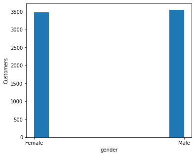

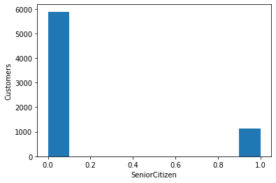

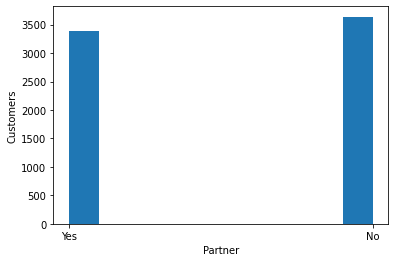

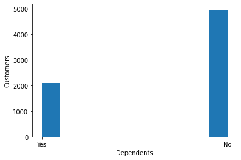

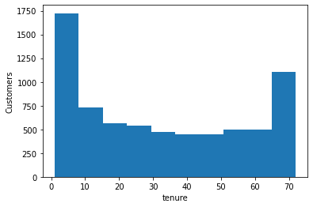

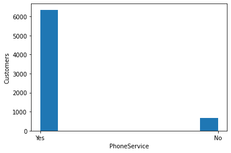

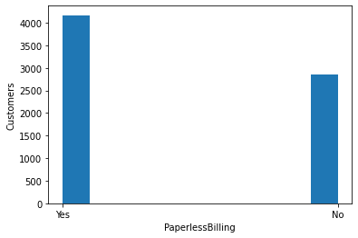

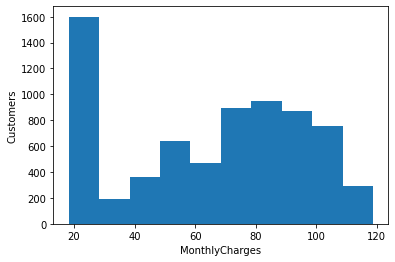

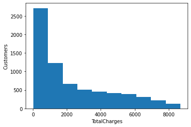

```python
cols = ['gender', 'SeniorCitizen', 'Partner', 'Dependents',
       'tenure', 'PhoneService', 'PaperlessBilling',
        'MonthlyCharges', 'TotalCharges']
plt.figure(figsize=(6, 5))
for col in cols:
    plt.hist(df[col])
    plt.xlabel(col)
    plt.ylabel("Customers")
    plt.show()
```

### We can observe the following information from the plots above for numeric data:

##### The customers' genders are distributed equally i.e. both male and female customers occupy half the dataset

##### Very few of the customers are senior citizens

##### There are about as many customers who are married as there are ones that are not

##### Most of the customers dont have any dependents. In fact, the number of customers that have dependents is less than half of those that do have

##### Large number of customers (almost 1750) keep subscribed for 10 months i,.e. they are newer customers, then second highest group of customers(~1100) stay for almost 65-70 months, who are part of the loyal group. Rest of the customers are distributed almost equally (500-750 customers) for other brackets of tenure in between

##### Almost all customers avail the phone services, with around 700 of them not having any phone service

##### Most people opt for paperless billing but there is quite a number of customers that dont want the paperless billing service

##### The group of customers that is largest pay about 20-30 dollars each month, which drops quite low in the 30-40 dollar bracket. From there number of customers increases as the charges increase till the 80-90 dollar bracket, while post that the number of customers drastically decrease as we reach the 110-20 dollar bracket. Therefore we can say that the monthly charges range from 18 dollars to 118 dollars

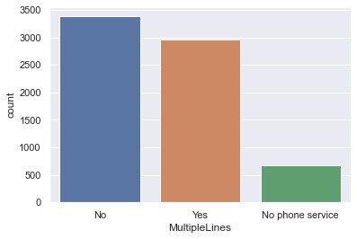

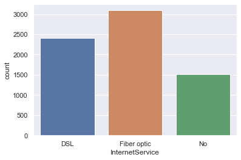

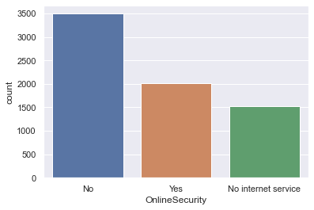

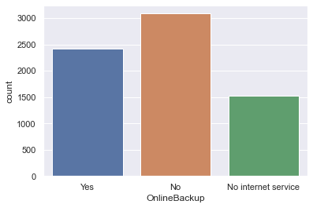

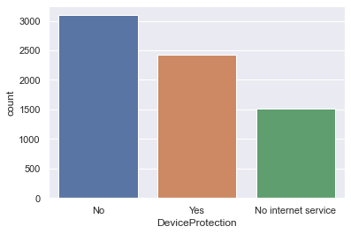

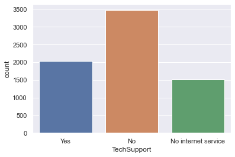

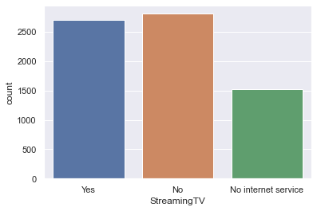

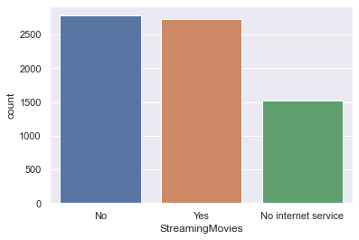

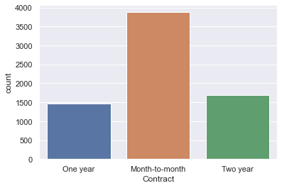

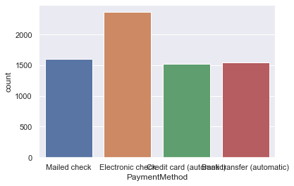

```python
catcols = ["MultipleLines", "InternetService", "OnlineSecurity",
        "OnlineBackup", "DeviceProtection", "TechSupport", "StreamingTV",
        "StreamingMovies", "Contract", "PaymentMethod"]
sns.set_theme(style="darkgrid")

for col in catcols:
    ax_grid = sns.countplot(x=col, data=df)
    plt.show()
```

### We can observe the following information from the plots above for categorical data:

##### Very less people have not opted for phone service, but out of those that have, they are divided almost equally between users that have opted for multiple lines and those that have not

##### Around 1500 people do not require the Internet services

##### Out of those that do, more people opt for fiber optic connection rather than DSL

##### From people that have internet services, more do not opt for online security, device protection, online backup and tech support than those that do avail these services.

##### The amount of customers that opt for streaming movies and tv shows or dont are pretty much equally distributed, divided into half of the data

##### Out of all those subscribed, a large majority (almost 3900) prefer a month-to-month basis contract, while those that prefer long term contracts are pretty much equal with 2 year contract customers taking the lead.

##### The Payment method plot implies that customers like to pay by electronic checks the most, while the rest are equally distributed, i.e. bank transfer, credit card and mailed checks.

```python
def Lencode_vars(df, cols):                              #Label Encoding for correlation matrix
    for col in cols:
        df[col] = df[col].astype('category')            #changing column type to category to encode
        d = dict(enumerate(df[col].cat.categories))     #creating dictionary to map code with category and print it
        print(col)
        print(d)
        print('\n')
        df[col] = df[col].cat.codes                    #converting col to encoded column
cols = ["gender", "Partner", "Dependents", "PhoneService", "MultipleLines",
        "InternetService", "OnlineSecurity", "OnlineBackup", "DeviceProtection", "TechSupport", "StreamingTV",
        "StreamingMovies", "Contract", "PaperlessBilling", "PaymentMethod", "Churn"]
df_Lencoded = df.copy()
Lencode_vars(df_Lencoded,cols)
```

```
gender
{0: 'Female', 1: 'Male'}


Partner
{0: 'No', 1: 'Yes'}


Dependents
{0: 'No', 1: 'Yes'}


PhoneService
{0: 'No', 1: 'Yes'}


MultipleLines
{0: 'No', 1: 'No phone service', 2: 'Yes'}


InternetService
{0: 'DSL', 1: 'Fiber optic', 2: 'No'}


OnlineSecurity
{0: 'No', 1: 'No internet service', 2: 'Yes'}


OnlineBackup
{0: 'No', 1: 'No internet service', 2: 'Yes'}


DeviceProtection
{0: 'No', 1: 'No internet service', 2: 'Yes'}


TechSupport
{0: 'No', 1: 'No internet service', 2: 'Yes'}


StreamingTV
{0: 'No', 1: 'No internet service', 2: 'Yes'}


StreamingMovies
{0: 'No', 1: 'No internet service', 2: 'Yes'}


Contract
{0: 'Month-to-month', 1: 'One year', 2: 'Two year'}


PaperlessBilling
{0: 'No', 1: 'Yes'}


PaymentMethod
{0: 'Bank transfer (automatic)', 1: 'Credit card (automatic)', 2: 'Electronic check', 3: 'Mailed check'}


Churn
{0: 'No', 1: 'Yes'}
```

```python
corr_matrix = df_Lencoded[["gender", "SeniorCitizen", "Partner", "Dependents", "tenure", "PhoneService", "MultipleLines",
        "InternetService", "OnlineSecurity", "OnlineBackup", "DeviceProtection", "TechSupport", "StreamingTV",
        "StreamingMovies", "Contract", "PaperlessBilling", "PaymentMethod", "MonthlyCharges", "TotalCharges", "Churn"]].corr()
corr_matrix
```

|  | gender | SeniorCitizen | Partner | Dependents | tenure | PhoneService | MultipleLines | InternetService | OnlineSecurity | OnlineBackup | DeviceProtection | TechSupport | StreamingTV | StreamingMovies | Contract | PaperlessBilling | PaymentMethod | MonthlyCharges | TotalCharges | Churn |
| --- | --- | --- | --- | --- | --- | --- | --- | --- | --- | --- | --- | --- | --- | --- | --- | --- | --- | --- | --- | --- |
| gender | 1.000000 | -0.001819 | -0.001379 | 0.010349 | 0.005285 | -0.007515 | -0.006908 | -0.002236 | -0.014899 | -0.011920 | 0.001348 | -0.006695 | -0.005624 | -0.008920 | 0.000095 | -0.011902 | 0.016942 | -0.013779 | 0.000048 | -0.008545 |
| SeniorCitizen | -0.001819 | 1.000000 | 0.016957 | -0.210550 | 0.015683 | 0.008392 | 0.146287 | -0.032160 | -0.127937 | -0.013355 | -0.021124 | -0.151007 | 0.031019 | 0.047088 | -0.141820 | 0.156258 | -0.038158 | 0.219874 | 0.102411 | 0.150541 |
| Partner | -0.001379 | 0.016957 | 1.000000 | 0.452269 | 0.381912 | 0.018397 | 0.142717 | 0.000513 | 0.150610 | 0.153045 | 0.165614 | 0.126488 | 0.136679 | 0.129907 | 0.294094 | -0.013957 | -0.156232 | 0.097825 | 0.319072 | -0.149982 |
| Dependents | 0.010349 | -0.210550 | 0.452269 | 1.000000 | 0.163386 | -0.001078 | -0.024975 | 0.044030 | 0.151198 | 0.090231 | 0.079723 | 0.132530 | 0.046214 | 0.022088 | 0.240556 | -0.110131 | -0.041989 | -0.112343 | 0.064653 | -0.163128 |
| tenure | 0.005285 | 0.015683 | 0.381912 | 0.163386 | 1.000000 | 0.007877 | 0.343673 | -0.029835 | 0.327283 | 0.372434 | 0.372669 | 0.324729 | 0.290572 | 0.296785 | 0.676734 | 0.004823 | -0.370087 | 0.246862 | 0.825880 | -0.354049 |
| PhoneService | -0.007515 | 0.008392 | 0.018397 | -0.001078 | 0.007877 | 1.000000 | -0.020504 | 0.387266 | -0.014163 | 0.024040 | 0.004718 | -0.018136 | 0.056393 | 0.043025 | 0.003019 | 0.016696 | -0.005499 | 0.248033 | 0.113008 | 0.011691 |
| MultipleLines | -0.006908 | 0.146287 | 0.142717 | -0.024975 | 0.343673 | -0.020504 | 1.000000 | -0.108849 | 0.007306 | 0.117276 | 0.122614 | 0.010941 | 0.175403 | 0.181705 | 0.111029 | 0.165306 | -0.176598 | 0.433905 | 0.453202 | 0.038043 |
| InternetService | -0.002236 | -0.032160 | 0.000513 | 0.044030 | -0.029835 | 0.387266 | -0.108849 | 1.000000 | -0.028003 | 0.036735 | 0.045558 | -0.025626 | 0.108190 | 0.097967 | 0.099579 | -0.138166 | 0.084504 | -0.322173 | -0.175691 | -0.047097 |
| OnlineSecurity | -0.014899 | -0.127937 | 0.150610 | 0.151198 | 0.327283 | -0.014163 | 0.007306 | -0.028003 | 1.000000 | 0.184942 | 0.175789 | 0.284875 | 0.044399 | 0.056313 | 0.373980 | -0.157723 | -0.096593 | -0.053576 | 0.254473 | -0.289050 |
| OnlineBackup | -0.011920 | -0.013355 | 0.153045 | 0.090231 | 0.372434 | 0.024040 | 0.117276 | 0.036735 | 0.184942 | 1.000000 | 0.187646 | 0.195581 | 0.147085 | 0.137083 | 0.280617 | -0.012697 | -0.125534 | 0.119943 | 0.375556 | -0.195290 |
| DeviceProtection | 0.001348 | -0.021124 | 0.165614 | 0.079723 | 0.372669 | 0.004718 | 0.122614 | 0.045558 | 0.175789 | 0.187646 | 1.000000 | 0.240476 | 0.275947 | 0.289309 | 0.350067 | -0.037596 | -0.136460 | 0.163984 | 0.389066 | -0.177883 |
| TechSupport | -0.006695 | -0.151007 | 0.126488 | 0.132530 | 0.324729 | -0.018136 | 0.010941 | -0.025626 | 0.284875 | 0.195581 | 0.240476 | 1.000000 | 0.161168 | 0.162530 | 0.425072 | -0.113617 | -0.104544 | -0.008237 | 0.276890 | -0.282232 |
| StreamingTV | -0.005624 | 0.031019 | 0.136679 | 0.046214 | 0.290572 | 0.056393 | 0.175403 | 0.108190 | 0.044399 | 0.147085 | 0.275947 | 0.161168 | 1.000000 | 0.435354 | 0.226826 | 0.097379 | -0.104782 | 0.337156 | 0.392472 | -0.036303 |
| StreamingMovies | -0.008920 | 0.047088 | 0.129907 | 0.022088 | 0.296785 | 0.043025 | 0.181705 | 0.097967 | 0.056313 | 0.137083 | 0.289309 | 0.162530 | 0.435354 | 1.000000 | 0.232478 | 0.083901 | -0.112009 | 0.335761 | 0.398088 | -0.038802 |
| Contract | 0.000095 | -0.141820 | 0.294094 | 0.240556 | 0.676734 | 0.003019 | 0.111029 | 0.099579 | 0.373980 | 0.280617 | 0.350067 | 0.425072 | 0.226826 | 0.232478 | 1.000000 | -0.175475 | -0.229636 | -0.072739 | 0.450306 | -0.396150 |
| PaperlessBilling | -0.011902 | 0.156258 | -0.013957 | -0.110131 | 0.004823 | 0.016696 | 0.165306 | -0.138166 | -0.157723 | -0.012697 | -0.037596 | -0.113617 | 0.097379 | 0.083901 | -0.175475 | 1.000000 | -0.061348 | 0.351930 | 0.157830 | 0.191454 |
| PaymentMethod | 0.016942 | -0.038158 | -0.156232 | -0.041989 | -0.370087 | -0.005499 | -0.176598 | 0.084504 | -0.096593 | -0.125534 | -0.136460 | -0.104544 | -0.104782 | -0.112009 | -0.229636 | -0.061348 | 1.000000 | -0.192500 | -0.330594 | 0.107852 |
| MonthlyCharges | -0.013779 | 0.219874 | 0.097825 | -0.112343 | 0.246862 | 0.248033 | 0.433905 | -0.322173 | -0.053576 | 0.119943 | 0.163984 | -0.008237 | 0.337156 | 0.335761 | -0.072739 | 0.351930 | -0.192500 | 1.000000 | 0.651065 | 0.192858 |
| TotalCharges | 0.000048 | 0.102411 | 0.319072 | 0.064653 | 0.825880 | 0.113008 | 0.453202 | -0.175691 | 0.254473 | 0.375556 | 0.389066 | 0.276890 | 0.392472 | 0.398088 | 0.450306 | 0.157830 | -0.330594 | 0.651065 | 1.000000 | -0.199484 |
| Churn | -0.008545 | 0.150541 | -0.149982 | -0.163128 | -0.354049 | 0.011691 | 0.038043 | -0.047097 | -0.289050 | -0.195290 | -0.177883 | -0.282232 | -0.036303 | -0.038802 | -0.396150 | 0.191454 | 0.107852 | 0.192858 | -0.199484 | 1.000000 |

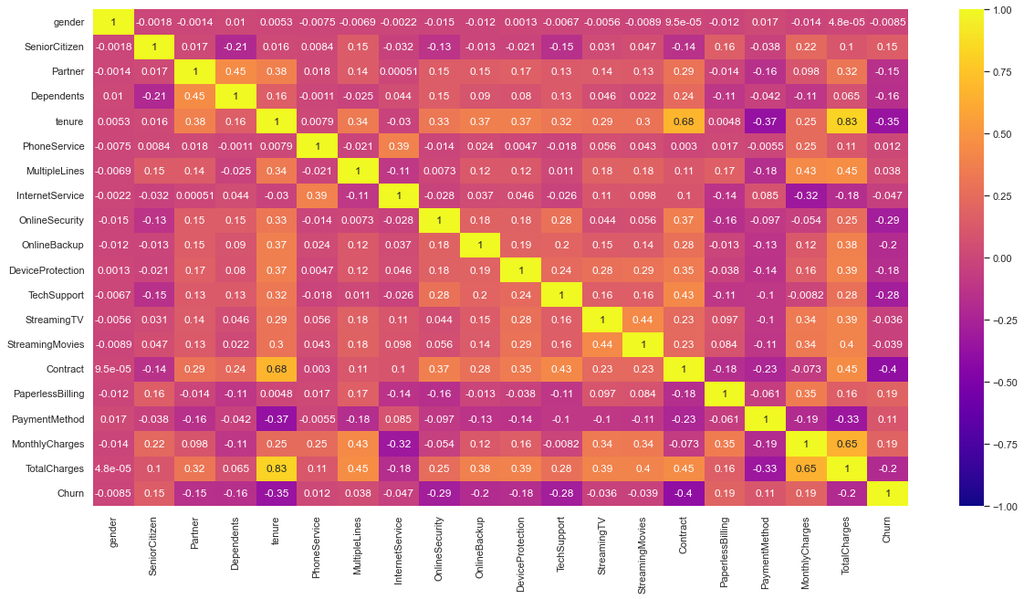

```python
plt.figure(figsize=(20,10))
sns.heatmap(corr_matrix,annot=True,cmap='plasma',vmin=-1,vmax=1)
plt.show()
```

#### From the heatmap, we can observe that:

##### Tenure and Total charges are highly correlated. This means that the customers that are loyal and stay subscribed for longest have higher total charges, which is obvious.

##### Tenure is also very highly correlated with contract feature, indicating that the type of contract has an important role to play in the subscription length of a customer.

##### Gender has low correlation with all other feature hence there is nothing to analyse there

##### Senior citizenship has low correlation with Monthly charges, Billing method, Churn and negatively corellated with dependents.

##### Partner feature is slightly correlated with Total Charges and Contract, and a bit more correlated with tenure and Dependents. This means that those customers with partners tend to subscribe for longer and also have dependents.

##### Dependents feature is slightly correlated with Contract

##### Phone service is correlated with Internet services i.e. quite a few people that opt for phone services also add internet services to their package

##### Multiple lines option is fairly correlated with Monthly and Total charges, i.e. the higher the charges more chance of customer having multiple lines. It is also slightly correlated with most internet services and bit more correlated with tenure of customer

##### Most internet services such as online security, online backup, device protection, tech support etc fairly well correlated with Total Charges, Contract and Tenure of customer

##### Contract is fairly well correlated to Total Charges,Tech Supportm and other online services

##### Billing preference is not correlated with many deatures except Monthly Charges, indicating some customers like to get Paperless bills if they are paying higher charges monthly

#### Now looking at the Target variable column Churn, we can infer the following:

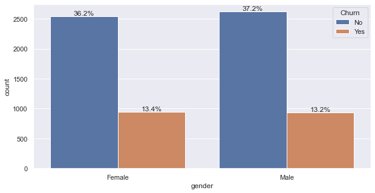

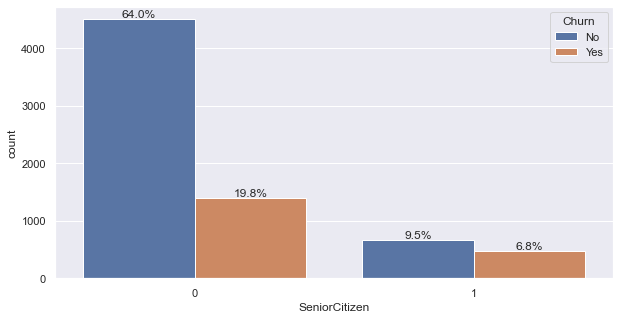

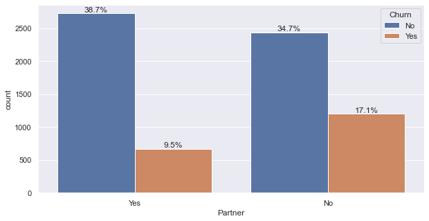

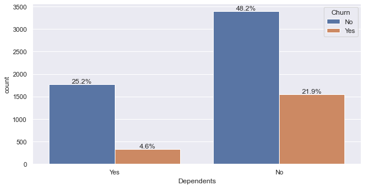

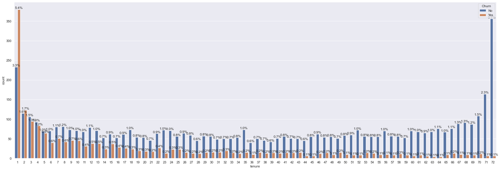

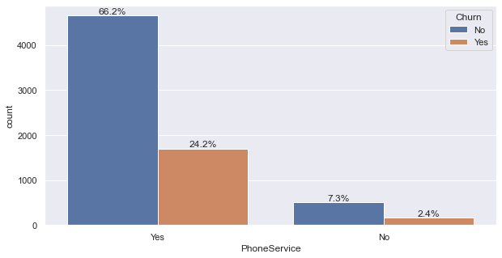

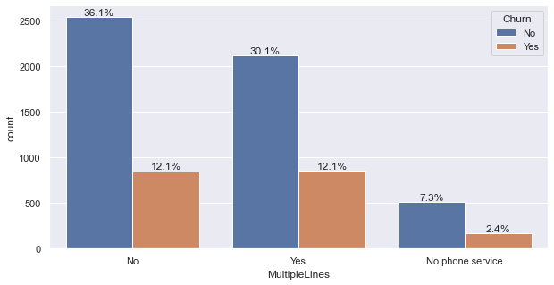

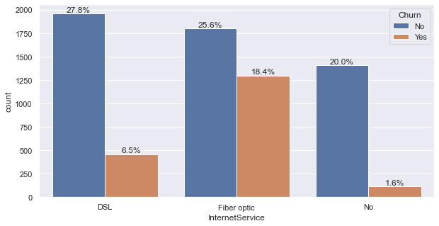

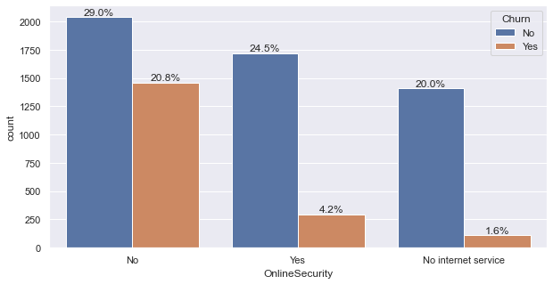

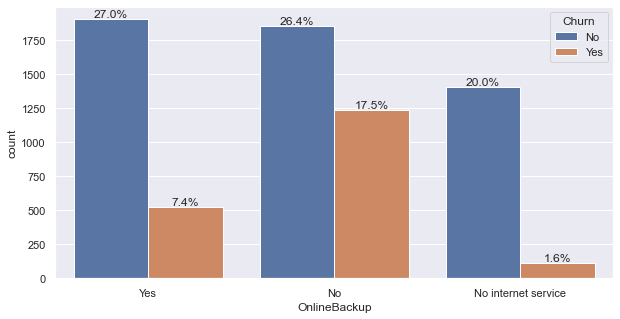

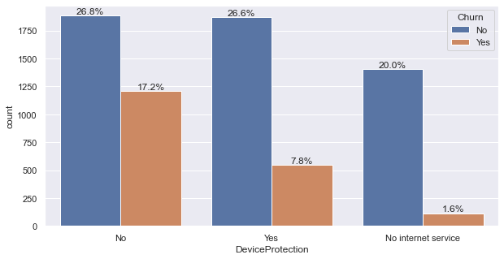

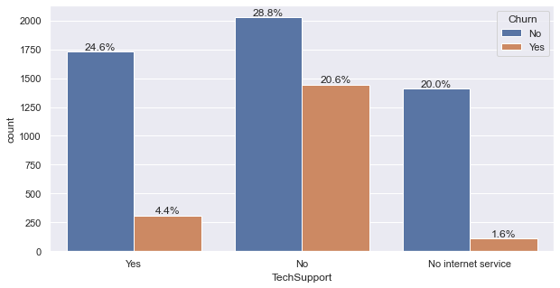

[6 more figures not shown]

```python
for i in df:
    if i == 'tenure':
        fig, ax = plt.subplots(figsize=(30, 10))
    elif i in ['MonthlyCharges', 'TotalCharges']:
        continue
    else:
        fig, ax = plt.subplots(figsize=(10, 5))

    ax = sns.countplot(x=i,hue='Churn', data=df)

    for c in ax.containers:

        # custom label calculates percent and add an empty string so 0 value bars don't have a number
        labels = [f'{h/df.shape[0]*100:0.1f}%' if (h := v.get_height()) > 0 else '' for v in c]
        ax.bar_label(c, labels=labels, label_type='edge')
    plt.show()
```

### Analysis churn wrt to other columns

##### Those with partners tend to churn less than customers that dont.

##### Those with dependents have a less amount of churn than those who dont, where churn rate is higher

##### Customers churn rate decreases as the tenure increases, with most customers dropping services in a month of starting

##### There is no discernible relationship of churn customers wrt Phone Service and Multiple Lines

##### More people who opted for Fiber Optic tend to churn than those that use DSL or no internet

##### For other Internet Services, more people tend to churn that do not opt for such services if they have internet

##### There is no difference in churn rate for customers who opt to stream movies and TV

##### Churn is highly correlated with Contract, and those that opt for monthly basis contracts tend to churn more than those that have year long contracts

##### Those who opt for paperless billing also churn more than those who dont

##### Customers that pay by electronic check have a very high rate of churn than those that pay by bank transfer or credit card

##### The customers that are still subscribing is 73.4%, and those that drop services are 26.6%, hence the data is skewed.

## From the above analysis, we can now calculate the correlation of numerical/independent categories wrt Churn

```python
cols = ['gender', 'SeniorCitizen', 'Partner', 'Dependents',
       'tenure', 'PhoneService', 'PaperlessBilling',
        'MonthlyCharges', 'TotalCharges']
corr_matrix = df_Lencoded[cols].corr()
corr_matrix
```

|  | gender | SeniorCitizen | Partner | Dependents | tenure | PhoneService | PaperlessBilling | MonthlyCharges | TotalCharges |
| --- | --- | --- | --- | --- | --- | --- | --- | --- | --- |
| gender | 1.000000 | -0.001819 | -0.001379 | 0.010349 | 0.005285 | -0.007515 | -0.011902 | -0.013779 | 0.000048 |
| SeniorCitizen | -0.001819 | 1.000000 | 0.016957 | -0.210550 | 0.015683 | 0.008392 | 0.156258 | 0.219874 | 0.102411 |
| Partner | -0.001379 | 0.016957 | 1.000000 | 0.452269 | 0.381912 | 0.018397 | -0.013957 | 0.097825 | 0.319072 |
| Dependents | 0.010349 | -0.210550 | 0.452269 | 1.000000 | 0.163386 | -0.001078 | -0.110131 | -0.112343 | 0.064653 |
| tenure | 0.005285 | 0.015683 | 0.381912 | 0.163386 | 1.000000 | 0.007877 | 0.004823 | 0.246862 | 0.825880 |
| PhoneService | -0.007515 | 0.008392 | 0.018397 | -0.001078 | 0.007877 | 1.000000 | 0.016696 | 0.248033 | 0.113008 |
| PaperlessBilling | -0.011902 | 0.156258 | -0.013957 | -0.110131 | 0.004823 | 0.016696 | 1.000000 | 0.351930 | 0.157830 |
| MonthlyCharges | -0.013779 | 0.219874 | 0.097825 | -0.112343 | 0.246862 | 0.248033 | 0.351930 | 1.000000 | 0.651065 |
| TotalCharges | 0.000048 | 0.102411 | 0.319072 | 0.064653 | 0.825880 | 0.113008 | 0.157830 | 0.651065 | 1.000000 |

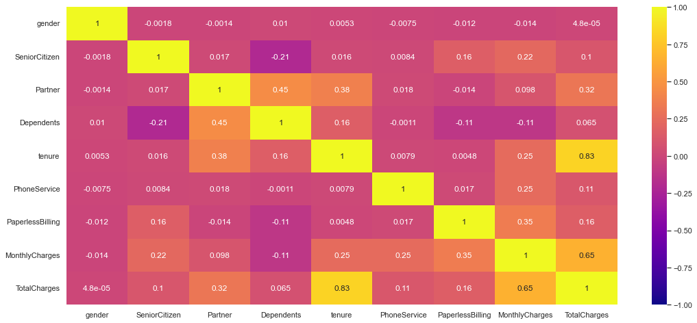

```python
plt.figure(figsize=(18,8))
sns.heatmap(corr_matrix,annot=True,cmap='plasma',vmin=-1,vmax=1)
plt.show()
```

#### We can observe that Total Charges is dependent on Monthly Charges and tenure. Hence, we can drop this column for our analysis.

```python
df.drop('TotalCharges', axis=1, inplace=True)
df_Lencoded.drop('TotalCharges', axis=1, inplace=True)
df_encoded.drop('TotalCharges', axis=1, inplace=True)
```

```python
print(df_encoded.info())
```

```
<class 'pandas.core.frame.DataFrame'>
Int64Index: 7032 entries, 0 to 7042
Data columns (total 40 columns):
 #   Column                                   Non-Null Count  Dtype
---  ------                                   --------------  -----
 0   gender                                   7032 non-null   int64
 1   SeniorCitizen                            7032 non-null   int64
 2   Partner                                  7032 non-null   int64
 3   Dependents                               7032 non-null   int64
 4   tenure                                   7032 non-null   int64
 5   PhoneService                             7032 non-null   int64
 6   PaperlessBilling                         7032 non-null   int64
 7   MonthlyCharges                           7032 non-null   float64
 8   Churn                                    7032 non-null   int64
 9   MultipleLines_No                         7032 non-null   uint8
```

[output cut: 33 more lines]

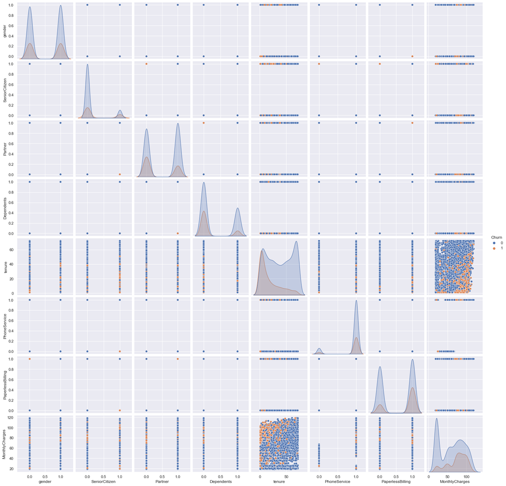

```python
df_num = df_Lencoded[['gender', 'SeniorCitizen', 'Partner', 'Dependents',
       'tenure', 'PhoneService', 'PaperlessBilling',
        'MonthlyCharges', 'Churn']]
sns.pairplot(df_num, hue="Churn")
```

#### From the above pairplots we can infer that

#### Gender does not have much role in churn

#### Churn rate is high in senior citizens. Churn is more prominent for senior citizens that do not have very long tenure i.e. 0-25 months approx.

#### Those with Partners tend to not churn if they have longer tenure. Those without partners who pay higher monthly charges (75-100 dollars) tend to churn.

#### Those with Phone Services, those who opt for paperless billing and also have shorter tenure tend to churn.

#### People with monthly charges in the 65-100 dollar range tend to churn if they are senior citizens, partnerless/dependentless

#### There is a high concentration of churned customers who have short tenure (0-30 months) but pay high monthly charges (65-110 dollars)

# EDA Summary

#### Churn is negatively correlated with Dependents, Partner and Tenure

#### Most customers are on month to month basis, who have a high probabilty to churn

```python
X = df_encoded.drop('Churn',axis=1)
Y = df_encoded['Churn']

## Split the data
X_train, X_test, Y_train, Y_test = train_test_split(X,Y,test_size=0.30)
print(X_train.shape,X_test.shape)
print(Y_train.shape,Y_test.shape)

## Scaling the data using standard scalar
ss = StandardScaler()

X_train.iloc[:,:] = ss.fit_transform(X_train.iloc[:,:])
X_test.iloc[:,:] = ss.transform(X_test.iloc[:,:])
```

```
(4922, 39) (2110, 39)
(4922,) (2110,)
```

# Logistic Regression

```python
log_reg = LogisticRegression()
log_reg.fit(X_train,Y_train)
```

```
LogisticRegression()
```

```python
y_pred_LR = log_reg.predict(X_test)
```

```python
accuracy_score(Y_test,y_pred_LR)
```

```
0.8109004739336493
```

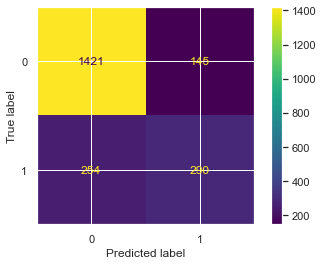

```python
## Confusion matrix
from sklearn.metrics import plot_confusion_matrix
plot_confusion_matrix(log_reg, X_test, Y_test)
plt.show()
```

```python
from sklearn.metrics import classification_report
print(classification_report(Y_test,y_pred_LR))
```

```
              precision    recall  f1-score   support

           0       0.85      0.91      0.88      1566
           1       0.67      0.53      0.59       544

    accuracy                           0.81      2110
   macro avg       0.76      0.72      0.73      2110
weighted avg       0.80      0.81      0.80      2110
```

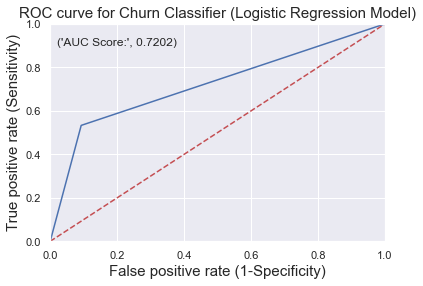

```python
from sklearn.metrics import roc_curve
from sklearn import metrics
fpr, tpr, thresholds = roc_curve(Y_test, y_pred_LR)

# plot the ROC curve
plt.plot(fpr, tpr)

# set limits for x and y axes
plt.xlim([0.0, 1.0])
plt.ylim([0.0, 1.0])

# plot the straight line showing worst prediction for the model
plt.plot([0, 1], [0, 1],'r--')

# add plot and axes labels
# set text size using 'fontsize'
plt.title('ROC curve for Churn Classifier (Logistic Regression Model)', fontsize = 15)
plt.xlabel('False positive rate (1-Specificity)', fontsize = 15)
plt.ylabel('True positive rate (Sensitivity)', fontsize = 15)

# add the AUC score to the plot
# 'x' and 'y' gives position of the text
# 's' is the text
# use round() to round-off the AUC score upto 4 digits
plt.text(x = 0.02, y = 0.9, s = ('AUC Score:', round(metrics.roc_auc_score(Y_test, y_pred_LR),4)))

# plot the grid
plt.grid(True)
```

# Naive Bayes Classification

```python
from sklearn.naive_bayes import GaussianNB

gnb = GaussianNB()
gnb.fit(X_train, Y_train)
```

```
GaussianNB()
```

```python
## compute y predicted labels
y_pred_gnb = gnb.predict(X_test)
y_pred_gnb[:10]
```

```
array([0, 1, 1, 1, 0, 1, 1, 0, 0, 1], dtype=int64)
```

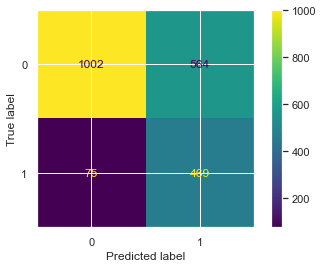

```python
## Confusion matrix
from sklearn.metrics import plot_confusion_matrix
plot_confusion_matrix(gnb, X_test, Y_test)
plt.show()
```

```python
## Compute precision, recall and F1-score
from sklearn.metrics import classification_report
print(classification_report(Y_test,y_pred_gnb))
```

```
              precision    recall  f1-score   support

           0       0.93      0.64      0.76      1566
           1       0.45      0.86      0.59       544

    accuracy                           0.70      2110
   macro avg       0.69      0.75      0.68      2110
weighted avg       0.81      0.70      0.72      2110
```

```python
## accuracy
print('accuracy:',accuracy_score(Y_test,y_pred_gnb))
```

```
accuracy: 0.6971563981042654
```

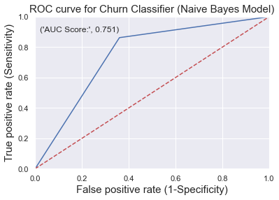

```python
from sklearn.metrics import roc_curve
from sklearn import metrics
fpr, tpr, thresholds = roc_curve(Y_test, y_pred_gnb)

# plot the ROC curve
plt.plot(fpr, tpr)

# set limits for x and y axes
plt.xlim([0.0, 1.0])
plt.ylim([0.0, 1.0])

# plot the straight line showing worst prediction for the model
plt.plot([0, 1], [0, 1],'r--')

# add plot and axes labels
# set text size using 'fontsize'
plt.title('ROC curve for Churn Classifier (Naive Bayes Model)', fontsize = 15)
plt.xlabel('False positive rate (1-Specificity)', fontsize = 15)
plt.ylabel('True positive rate (Sensitivity)', fontsize = 15)

# add the AUC score to the plot
# 'x' and 'y' gives position of the text
# 's' is the text
# use round() to round-off the AUC score upto 4 digits
plt.text(x = 0.02, y = 0.9, s = ('AUC Score:', round(metrics.roc_auc_score(Y_test, y_pred_gnb),4)))

# plot the grid
plt.grid(True)
```

# K-Nearest Neighbours Classification

```python
from sklearn.neighbors import KNeighborsClassifier

knn = KNeighborsClassifier()
knn.fit(X_train,Y_train)
```

```
KNeighborsClassifier()
```

```python
## compute y predicted labels
y_pred_knn = knn.predict(X_test)
y_pred_knn[:10]
```

```
array([0, 1, 1, 0, 0, 1, 0, 0, 0, 0], dtype=int64)
```

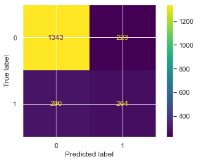

```python
## Confusion matrix
plot_confusion_matrix(knn, X_test, Y_test)
plt.show()
```

```python
print(classification_report(Y_test,y_pred_knn))
```

```
              precision    recall  f1-score   support

           0       0.83      0.86      0.84      1566
           1       0.54      0.49      0.51       544

    accuracy                           0.76      2110
   macro avg       0.68      0.67      0.68      2110
weighted avg       0.75      0.76      0.76      2110
```

```python
## accuracy
print('accuracy:',accuracy_score(Y_test,y_pred_knn))
```

```
accuracy: 0.761611374407583
```

### Choosing best value for k

```python
error_rate = []

for i in range(1,30):

    knn = KNeighborsClassifier(n_neighbors=i)
    knn.fit(X_train,Y_train)
    pred_i = knn.predict(X_test)
    error_rate.append(np.mean(pred_i != Y_test))
```

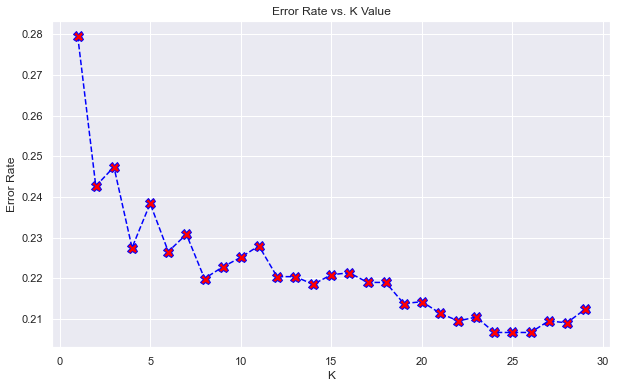

```python
plt.figure(figsize=(10,6))
plt.plot(range(1,30),error_rate,color='blue', linestyle='dashed', marker='X',
         markerfacecolor='red', markersize=10)
plt.title('Error Rate vs. K Value')
plt.xlabel('K')
plt.ylabel('Error Rate')
plt.show()
```

```python
knn_24 = KNeighborsClassifier(n_neighbors=24)
knn_24.fit(X_train,Y_train)

## y predicted
y_pred_knn_24 = knn_24.predict(X_test)

## accuracy
print('accuracy (k=24):',accuracy_score(Y_test,y_pred_knn_24))
```

```
accuracy (k=24): 0.7933649289099526
```

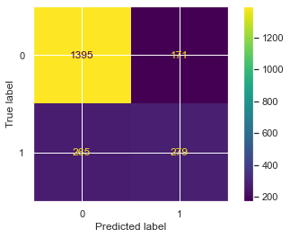

```python
## Confusion matrix
plot_confusion_matrix(knn_24, X_test, Y_test)
plt.show()
```

#### k = 24 has a 3% less error rate than deafult k=5, and hence gives a better result, so we can use this value.

```python
print(classification_report(Y_test,y_pred_knn_24))
```

```
              precision    recall  f1-score   support

           0       0.84      0.89      0.86      1566
           1       0.62      0.51      0.56       544

    accuracy                           0.79      2110
   macro avg       0.73      0.70      0.71      2110
weighted avg       0.78      0.79      0.79      2110
```

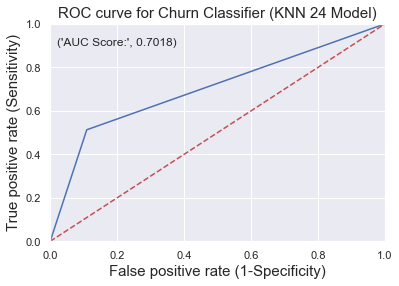

```python
from sklearn.metrics import roc_curve
from sklearn import metrics
fpr, tpr, thresholds = roc_curve(Y_test, y_pred_knn_24)

# plot the ROC curve
plt.plot(fpr, tpr)

# set limits for x and y axes
plt.xlim([0.0, 1.0])
plt.ylim([0.0, 1.0])

# plot the straight line showing worst prediction for the model
plt.plot([0, 1], [0, 1],'r--')

# add plot and axes labels
# set text size using 'fontsize'
plt.title('ROC curve for Churn Classifier (KNN 24 Model)', fontsize = 15)
plt.xlabel('False positive rate (1-Specificity)', fontsize = 15)
plt.ylabel('True positive rate (Sensitivity)', fontsize = 15)

# add the AUC score to the plot
# 'x' and 'y' gives position of the text
# 's' is the text
# use round() to round-off the AUC score upto 4 digits
plt.text(x = 0.02, y = 0.9, s = ('AUC Score:', round(metrics.roc_auc_score(Y_test, y_pred_knn_24),4)))

# plot the grid
plt.grid(True)
```

# Comparison of aforementioned classification models

### Accuracy:

#### Logistic Regression : 81.09%

#### Naive Bayes : 69.71%

#### KNN (k=24) : 79.33%

From above accuracy scores, we can observe that Naive Bayes has the least accuracy, KNN and LR are pretty close but LR has 2% better accuracy than KNN

### Precision (0,1):

#### Logistic Regression : 85%, 67%

#### Naive Bayes : 93%, 45%

#### KNN (k=24) : 84%, 62%

From above Precision scores, we understand that the Naive Bayes model has very high accuracy for predicting customers that will not churn but very low for those that do churn. On the other hand LR and KNN are very close with their precisions but LR is a more precise model for both values

### Recall (0,1):

#### Logistic Regression : 91%, 53%

#### Naive Bayes : 64%, 86%

#### KNN (k=24) : 89%, 51%

From above recall scores, we can see that Naive Bayes model can identify churned customers effectively but has very low accuracy in recalling those that do not churn. LR and KNN are again close with recall, with LR being a better model (by 2%) in both classes

### F1 scores (0,1):

#### Logistic Regression : 0.88, 0.59

#### Naive Bayes : 0.76, 0.59

#### KNN (k=24) : 0.86, 0.56

From above F1 scores, we can see that LR is the best model that can more accurately predict correct values

### AUC scores:

#### Logistic Regression : 0.72

#### Naive Bayes : 0.75

#### KNN (k=24) : 0.7

From above AUC scores, we can observe that there is not much difference between them, and since they are above 0.7 that means they are good predictions, though Naive Bayes has the highest AUC score.

### Comparing all the above data, we can affirm that:

#### Since AUC score of Naive Bayes is higher but it is not performing for other metrics, we can discard this model for our final selection.

#### AUC score of KNN and LR is pretty much the same, hence we can use the other metrics to select a better model. Considering Accuracy, Precision, Recall and F1 scores, Logistic Regression model has performed better than K Nearest Neighbours model.

# Hence, from all of the above comparisons, we can finally select Logistic Regression Model as our best trained model.

# Conclusion

After performing Exploratory data analysis on the given database, we can infer the following:

- The data is skewed as there are more number if customers that do not churn
- The target variable churn is positively correlated with Monthly Charges and Senior Citizenship
- The target variable churn is negatively correlated Tenure, Dependents and Partners
- There are very few loyal, long term customers and lots of new customers
- Customers paying bills every month or paying by electronic check have higher chance to churn
- Very less customers are availing specific internet services such as Device Protection, Technical Support, Online Backup and Security

After training data with different ML models and applying to testing data and comparing their performance metrics, we can confirm that Logistic Regression is the best trained model to classify customers and predict churn in the dataset.